# MSc_CW2_13175438_S_Khan

Sameer Khan

# 1. Bayesian Networks and Naïve Bayes Classifiers

**(a) Given a training dataset including 30 instances and a Bayesian network indicating the relationships between 3 features (i.e. Income, Student and Credit Rate), and the class attribute (i.e. Buy Computer), please create the conditional probability tables by hand.**

```r
kable(CPT_Buy, caption="Conditional Probability Table: Buy Computer")
```

Conditional Probability Table: Buy Computer

| Yes | No |
| --- | --- |
| 0.47 | 0.53 |

```r
kable(CPT_Income, caption="Conditional Probability Table: Income")
```

Conditional Probability Table: Income

| Buy_Computer | High_Income | Low_Income |
| --- | --- | --- |
| Yes | 0.36 | 0.64 |
| No | 0.44 | 0.56 |

```r
kable(CPT_Student, caption="Conditional Probability Table: Student")
```

Conditional Probability Table: Student

| Buy_Computer | Student_True | Student_False |
| --- | --- | --- |
| Yes | 0.50 | 0.50 |
| No | 0.69 | 0.31 |

```r
kable(CPT_Rating, caption="Conditional Probability Table: Credit Rating")
```

Conditional Probability Table: Credit Rating

| Buy_Computer | Income | Student | Rating_Excellent | Rating_Fair |
| --- | --- | --- | --- | --- |
| Yes | High | True | 0.50 | 0.50 |
| Yes | High | False | 0.67 | 0.33 |
| Yes | Low | True | 0.40 | 0.60 |
| Yes | Low | False | 0.67 | 0.33 |
| No | High | True | 0.50 | 0.50 |
| No | High | False | 0.67 | 0.33 |
| No | Low | True | 0.29 | 0.71 |
| No | Low | False | 0.50 | 0.50 |

**(b) Make predictions for 2 testing instances by using the Bayesian network classifier.**

**>> Instance 31 <<**

$P(BuyComputer=Yes \mid Income=Low, Student=False, Rating=Excellent)$

Proportional To: P(BuyComputer=Yes, Income=Low, Student=False, Rating=Excellent)

= P(Rating=Excellent | Income=Low, Student=False, BuyComputer=Yes) x P(Student=False | BuyComputer=Yes) x P(Income=Low | BuyComputer=Yes) x P(BuyComputer=Yes)

= 0.67 x 0.5 x 0.64 x 0.47 = **0.10**

$P(BuyComputer=No \mid Income=Low, Student=False, Rating=Excellent)$

Proportional To: P(BuyComputer=No, Income=Low, Student=False, Rating=Excellent)

= P(Rating=Excellent | Income=Low, Student=False, BuyComputer=No) x P(Student=False | BuyComputer=No) x P(Income=Low | BuyComputer=No) x P(BuyComputer=No)

= 0.5 x 0.31 x 0.56 x 0.53 = **0.05**

—> *Prediction for class attribute of instance 31: **BUY COMPUTER (YES)***

**>> Instance 32 <<**

$P(BuyComputer=Yes \mid Income=High, Student=False, Rating=Fair)$

Proportional To: P(BuyComputer=Yes, Income=High, Student=False, Rating=Fair)

= P(Rating=Fair | Income=High, Student=False, BuyComputer=Yes) x P(Student=False | BuyComputer=Yes) x P(Income=High | BuyComputer=Yes) x P(BuyComputer=Yes)

= 0.33 x 0.5 x 0.36 x 0.47 = **0.03**

$P(BuyComputer=No \mid Income=High, Student=False, Rating=Fair)$

Proportional To: P(BuyComputer=No, Income=High, Student=False, Rating=Fair)

= P(Rating=Fair | Income=High, Student=False, BuyComputer=No) x P(Student=False | BuyComputer=No) x P(Income=High | BuyComputer=No) x P(BuyComputer=No)

= 0.33 x 0.31 x 0.44 x 0.53 = **0.02**

—> *Prediction for class attribute of instance 32: **BUY COMPUTER (YES)***

**(c) Based on the conditional independence assumption between features, please create the conditional probability tables by hand.**

```r
kable(CPT_Buy, caption="Conditional Probability Table (Independence Assumption): Buy Computer")
```

Conditional Probability Table (Independence Assumption): Buy Computer

| Yes | No |
| --- | --- |
| 0.47 | 0.53 |

```r
kable(CPT_Income, caption="Conditional Probability Table (Independence Assumption): Income")
```

Conditional Probability Table (Independence Assumption): Income

| Buy_Computer | High_Income | Low_Income |
| --- | --- | --- |
| Yes | 0.36 | 0.64 |
| No | 0.44 | 0.56 |

```r
kable(CPT_Student, caption="Conditional Probability Table (Independence Assumption): Student")
```

Conditional Probability Table (Independence Assumption): Student

| Buy_Computer | Student_True | Student_False |
| --- | --- | --- |
| Yes | 0.50 | 0.50 |
| No | 0.69 | 0.31 |

```r
kable(CPT_Rating_Ind, caption="Conditional Probability Table (Independence Assumption): Credit Rating")
```

Conditional Probability Table (Independence Assumption): Credit Rating

| Buy_Computer | Rating_Excellent_Ind | Rating_Fair_Ind |
| --- | --- | --- |
| Yes | 0.50 | 0.50 |
| No | 0.44 | 0.56 |

**(d) Make predictions for 2 testing instances by using the naïve Bayes classifier.**

**>> Instance 31 <<**

$P(BuyComputer=Yes \mid Income=Low, Student=False, Rating=Excellent)$

Proportional To: P(BuyComputer=Yes, Income=Low, Student=False, Rating=Excellent)

= P(Rating=Excellent | BuyComputer=Yes) x P(Student=False | BuyComputer=Yes) x P(Income=Low | BuyComputer=Yes) x P(BuyComputer=Yes)

= 0.5 x 0.5 x 0.64 x 0.47 = **0.08**

$P(BuyComputer=No \mid Income=Low, Student=False, Rating=Excellent)$

Proportional To: P(BuyComputer=No, Income=Low, Student=False, Rating=Excellent)

= P(Rating=Excellent | BuyComputer=No) x P(Student=False | BuyComputer=No) x P(Income=Low | BuyComputer=No) x P(BuyComputer=No)

= 0.44 x 0.31 x 0.56 x 0.53 = **0.04**

—> *Prediction for class attribute of instance 31: **BUY COMPUTER (YES)***

**>> Instance 32 <<**

$P(BuyComputer=Yes \mid Income=High, Student=False, Rating=Fair)$

Proportional To: P(BuyComputer=Yes, Income=High, Student=False, Rating=Fair)

= P(Rating=Fair | BuyComputer=Yes) x P(Student=False | BuyComputer=Yes) x P(Income=High | BuyComputer=Yes) x P(BuyComputer=Yes)

= 0.5 x 0.5 x 0.36 x 0.47 = **0.042**

$P(BuyComputer=No \mid Income=High, Student=False, Rating=Fair)$

Proportional To: P(BuyComputer=No, Income=High, Student=False, Rating=Fair)

= P(Rating=Fair | BuyComputer=No) x P(Student=False | BuyComputer=No) x P(Income=High | BuyComputer=No) x P(BuyComputer=No)

= 0.56 x 0.31 x 0.44 x 0.53 = **0.041**

# 2. Decision Trees and Random Forests

To predict room occupancy using the decision tree classification algorithm.

**(a) Load the room occupancy data and train a decision tree classifier. Evaluate the predictive performance by reporting the accuracy obtained on the testing datasset.**

```r
room.trainingset <- read.csv('RoomOccupancy_Training.txt')
room.testingset <- read.csv('RoomOccupancy_Testing.txt')

tree.room.train <- tree(Occupancy ~ ., data=room.trainingset)
summary(tree.room.train)
```

```
##
## Classification tree:
## tree(formula = Occupancy ~ ., data = room.trainingset)
## Variables actually used in tree construction:
## [1] "Light"       "Temperature" "CO2"         "Humidity"
## Number of terminal nodes:  6
## Residual mean deviance:  0.07156 = 142.7 / 1994
## Misclassification error rate: 0.0125 = 25 / 2000
```

```r
tree.room.pred <- predict(tree.room.train, newdata=room.testingset, type='class')
error <- mean(tree.room.pred != room.testingset$Occupancy)
accuracy <- mean(tree.room.pred == room.testingset$Occupancy)
table(tree.room.pred, room.testingset$Occupancy)
```

```
##
## tree.room.pred  No Yes
##            No  195  16
##            Yes  45  44
```

The Decision Tree classifier had an accuracy of 79.7%.

**(b) Output and analyse the tree learned by the decision tree algorithm, i.e. plot the tree structure and make a discussion about it.**

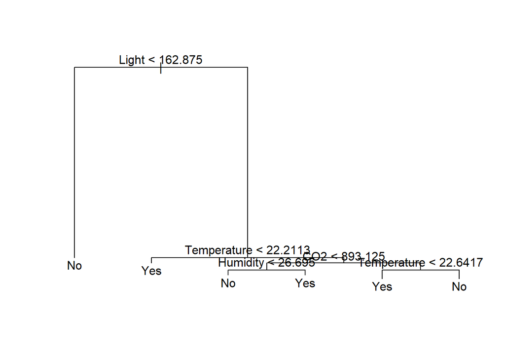

```r
plot(tree.room.train)
text(tree.room.train, pretty=0)
```

It is clear that light is the most important factor in determining occupancy, when considering a level below or above 162.875 lux. This makes intuitive sense, since overall visibility in a room will drive whether or not people may want to enter! Then, given a minimum lighting level, the next decision appears to be one based on room temperature, with a split at 22.2 degrees celcius. Anything above this, and further factors come into play, such as CO2 levels and humidity.

**(c) Train a random forests classifier, and evaluate the predictive performance by reporting the accuracy obtained on the testing dataset.**

```r
table(is.na(room.trainingset))  # Ensure no N/A values in data
```

```
##
## FALSE
## 12000
```

```r
set.seed(10)
bag.room <- randomForest(Occupancy ~ ., data=room.trainingset, importance=T)
print(bag.room)
```

```
##
## Call:
##  randomForest(formula = Occupancy ~ ., data = room.trainingset,      importance = T)
##                Type of random forest: classification
##                      Number of trees: 500
## No. of variables tried at each split: 2
##
##         OOB estimate of  error rate: 1.2%
## Confusion matrix:
##       No Yes class.error
## No  1432  13  0.00899654
## Yes   11 544  0.01981982
```

```r
bag.room.pred <- predict(bag.room, newdata=room.testingset, type='class')
bag_error <- mean(bag.room.pred != room.testingset$Occupancy)
bag_accuracy <- mean(bag.room.pred == room.testingset$Occupancy)
table(bag.room.pred, room.testingset$Occupancy)
```

```
##
## bag.room.pred  No Yes
##           No  181   7
##           Yes  59  53
```

**(d) Output and analyse the feature importance obtained by the random forests classifier.**

```r
importance(bag.room)
```

```
##                      No      Yes MeanDecreaseAccuracy MeanDecreaseGini
## Temperature   19.689081 15.44228             25.79024        111.14445
## Humidity      12.075356 18.22467             21.35971         31.23381
## Light         44.780111 64.05430             70.14899        397.59612
## CO2           13.306928 24.08906             26.43326        217.93772
## HumidityRatio  9.795357 15.48575             18.17000         43.15144
```

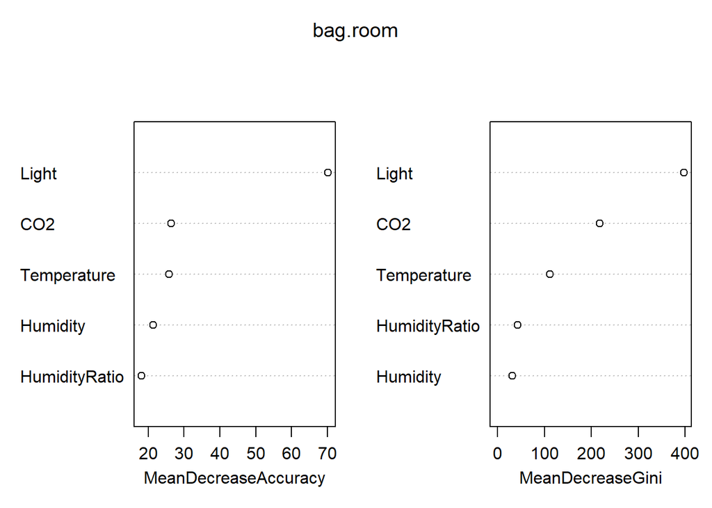

```r
varImpPlot(bag.room)
```

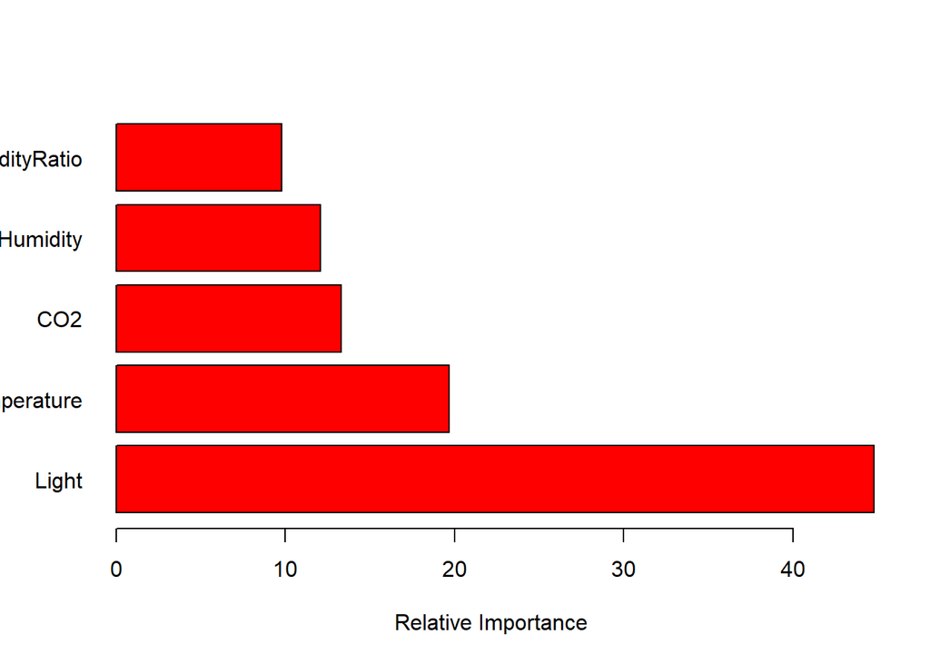

```r
barplot(sort(importance(bag.room)[,1], decreasing = TRUE), xlab = "Relative Importance", horiz = TRUE, col = 'red', las = 1)
```

Above plots display relative feature importance in ranked order, whereby Light levels are by far the most important. Co2 and Temperature are the next two variables with the largest mean decrease in Gini index.

# 3. SVM

To predict the wine quality using the support vector machine classification algorithm.

**(a) Download the wine quality data and use the training dataset to conduct the grid-search to find the optimal hyperparameters of svm by using the linear kernal.**

```r
wine.training <- read.csv('WineQuality_training.txt')
wine.testing <- read.csv('WineQuality_testing.txt')
head(wine.training)
```

|  | fixed.acidity | volatile.acidity | citric.acid | residual.sugar | chlorides | free.sulfur.dioxide | total.sulfur.dioxide | density | pH | sulphates | alcohol | quality |
| --- | --- | --- | --- | --- | --- | --- | --- | --- | --- | --- | --- | --- |
| 1 | 9.1 | 0.27 | 0.45 | 10.6 | 0.035 | 28 | 124 | 0.99700 | 3.20 | 0.46 | 10.4 | Good |
| 2 | 6.6 | 0.36 | 0.29 | 1.6 | 0.021 | 24 | 85 | 0.98965 | 3.41 | 0.61 | 12.4 | Good |
| 3 | 7.4 | 0.24 | 0.36 | 2.0 | 0.031 | 27 | 139 | 0.99055 | 3.28 | 0.48 | 12.5 | Good |
| 4 | 6.9 | 0.36 | 0.34 | 4.2 | 0.018 | 57 | 119 | 0.98980 | 3.28 | 0.36 | 12.7 | Good |
| 5 | 7.1 | 0.26 | 0.49 | 2.2 | 0.032 | 31 | 113 | 0.99030 | 3.37 | 0.42 | 12.9 | Good |
| 6 | 6.2 | 0.66 | 0.48 | 1.2 | 0.029 | 29 | 75 | 0.98920 | 3.33 | 0.39 | 12.8 | Good |

```r
str(wine.training)
```

```
## 'data.frame':    3000 obs. of  12 variables:
##  $ fixed.acidity       : num  9.1 6.6 7.4 6.9 7.1 6.2 6.2 6.8 6.7 6.7 ...
##  $ volatile.acidity    : num  0.27 0.36 0.24 0.36 0.26 0.66 0.66 0.26 0.23 0.23 ...
##  $ citric.acid         : num  0.45 0.29 0.36 0.34 0.49 0.48 0.48 0.42 0.31 0.31 ...
##  $ residual.sugar      : num  10.6 1.6 2 4.2 2.2 1.2 1.2 1.7 2.1 2.1 ...
##  $ chlorides           : num  0.035 0.021 0.031 0.018 0.032 0.029 0.029 0.049 0.046 0.046 ...
##  $ free.sulfur.dioxide : num  28 24 27 57 31 29 29 41 30 30 ...
##  $ total.sulfur.dioxide: num  124 85 139 119 113 75 75 122 96 96 ...
##  $ density             : num  0.997 0.99 0.991 0.99 0.99 ...
##  $ pH                  : num  3.2 3.41 3.28 3.28 3.37 3.33 3.33 3.47 3.33 3.33 ...
##  $ sulphates           : num  0.46 0.61 0.48 0.36 0.42 0.39 0.39 0.48 0.64 0.64 ...
##  $ alcohol             : num  10.4 12.4 12.5 12.7 12.9 12.8 12.8 10.5 10.7 10.7 ...
##  $ quality             : Factor w/ 2 levels "Bad","Good": 2 2 2 2 2 2 2 2 2 2 ...
```

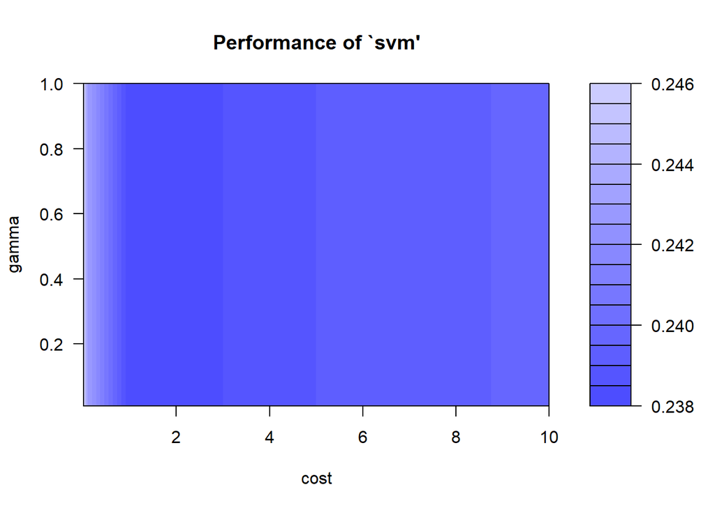

```r
set.seed(1)
tune.out <- tune(svm, quality ~ ., data=wine.training, kernel='linear',
                 ranges=list(cost=c(0.01, 0.1, 1, 5, 10),
                             gamma=c(0.01, 0.03, 0.1, 0.5, 1)))
plot(tune.out)
```

```r
summary(tune.out)
```

```
##
## Parameter tuning of 'svm':
##
## - sampling method: 10-fold cross validation
##
## - best parameters:
##  cost gamma
##     1  0.01
##
## - best performance: 0.238
##
## - Detailed performance results:
##     cost gamma     error dispersion
## 1   0.01  0.01 0.2460000 0.01623896
## 2   0.10  0.01 0.2430000 0.01636392
## 3   1.00  0.01 0.2380000 0.01886927
## 4   5.00  0.01 0.2390000 0.01771168
## 5  10.00  0.01 0.2396667 0.01855589
## 6   0.01  0.03 0.2460000 0.01623896
## 7   0.10  0.03 0.2430000 0.01636392
## 8   1.00  0.03 0.2380000 0.01886927
## 9   5.00  0.03 0.2390000 0.01771168
## 10 10.00  0.03 0.2396667 0.01855589
## 11  0.01  0.10 0.2460000 0.01623896
## 12  0.10  0.10 0.2430000 0.01636392
## 13  1.00  0.10 0.2380000 0.01886927
## 14  5.00  0.10 0.2390000 0.01771168
## 15 10.00  0.10 0.2396667 0.01855589
## 16  0.01  0.50 0.2460000 0.01623896
## 17  0.10  0.50 0.2430000 0.01636392
## 18  1.00  0.50 0.2380000 0.01886927
## 19  5.00  0.50 0.2390000 0.01771168
## 20 10.00  0.50 0.2396667 0.01855589
## 21  0.01  1.00 0.2460000 0.01623896
## 22  0.10  1.00 0.2430000 0.01636392
## 23  1.00  1.00 0.2380000 0.01886927
## 24  5.00  1.00 0.2390000 0.01771168
## 25 10.00  1.00 0.2396667 0.01855589
```

The best performance was 0.238, using the following optimal parameters: Cost = 1 Gamma = 0.01

**(b) Train a svm classifier by using the linear kernal and the corresponding optimal hyperparameters, then make predictions on the testing dataset, report the predictive performance.**

```r
svmfit.train.C1G001 <- svm(quality ~ ., data=wine.training, kernel='linear', cost=1, gamma=0.01, scale=T)
summary(svmfit.train.C1G001)
```

```
##
## Call:
## svm(formula = quality ~ ., data = wine.training, kernel = "linear",
##     cost = 1, gamma = 0.01, scale = T)
##
##
## Parameters:
##    SVM-Type:  C-classification
##  SVM-Kernel:  linear
##        cost:  1
##
## Number of Support Vectors:  1710
##
##  ( 855 855 )
##
##
## Number of Classes:  2
##
## Levels:
##  Bad Good
```

```r
svm.pred.c1g001 <- predict(svmfit.train.C1G001, newdata=wine.testing)
error <- mean(wine.testing$quality != svm.pred.c1g001)
table(wine.testing$quality, svm.pred.c1g001)
```

```
##       svm.pred.c1g001
##        Bad Good
##   Bad  104   38
##   Good  89  169
```

The classifer had an error rate of 32%.

**(c) Conduct the grid-search to find the optimal hyperparameters of svm by using the RBF kernal.**

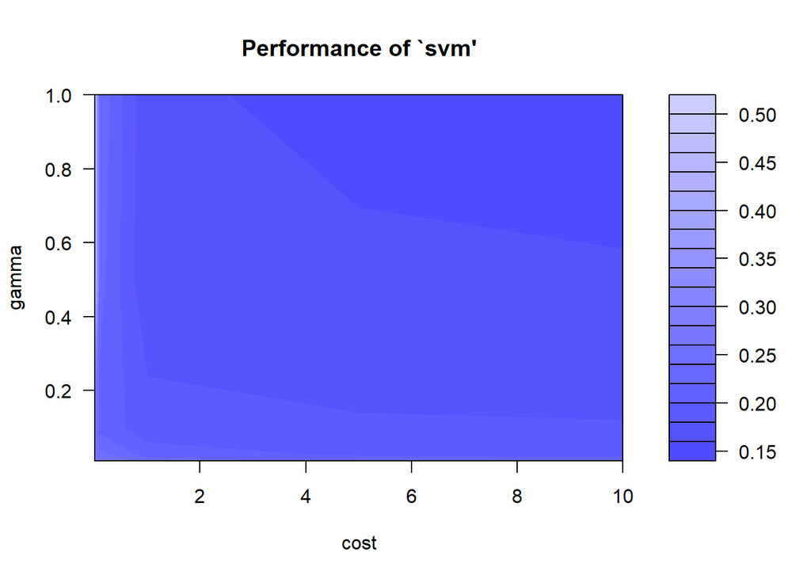

```r
set.seed(1)
tune.out.rbf <- tune(svm, quality ~ ., data=wine.training, kernel='radial',
                     ranges=list(cost=c(0.01, 0.1, 1, 5, 10),
                                 gamma=c(0.01, 0.03, 0.1, 0.5, 1)))
plot(tune.out.rbf)
```

```r
summary(tune.out.rbf)
```

```
##
## Parameter tuning of 'svm':
##
## - sampling method: 10-fold cross validation
##
## - best parameters:
##  cost gamma
##     5     1
##
## - best performance: 0.1563333
##
## - Detailed performance results:
##     cost gamma     error dispersion
## 1   0.01  0.01 0.2826667 0.02647151
## 2   0.10  0.01 0.2523333 0.02216938
## 3   1.00  0.01 0.2340000 0.01755415
## 4   5.00  0.01 0.2106667 0.02319004
## 5  10.00  0.01 0.2076667 0.02194550
## 6   0.01  0.03 0.2650000 0.02092019
## 7   0.10  0.03 0.2436667 0.01724550
## 8   1.00  0.03 0.2083333 0.02368778
## 9   5.00  0.03 0.1960000 0.03257660
## 10 10.00  0.03 0.1933333 0.03258417
## 11  0.01  0.10 0.2650000 0.01765583
## 12  0.10  0.10 0.2130000 0.02191172
## 13  1.00  0.10 0.1893333 0.03062316
## 14  5.00  0.10 0.1820000 0.02310470
## 15 10.00  0.10 0.1810000 0.02434576
## 16  0.01  0.50 0.4960000 0.07831245
## 17  0.10  0.50 0.2273333 0.02153378
## 18  1.00  0.50 0.1623333 0.02730938
## 19  5.00  0.50 0.1623333 0.03127141
## 20 10.00  0.50 0.1606667 0.03062316
## 21  0.01  1.00 0.5060000 0.04870673
## 22  0.10  1.00 0.2363333 0.04782814
## 23  1.00  1.00 0.1623333 0.03067351
## 24  5.00  1.00 0.1563333 0.02821653
## 25 10.00  1.00 0.1566667 0.02828427
```

The best performance was 0.1563, using the following optimal parameters: Cost = 5 Gamma = 1

**(d) Train a svm classifier by using the RBF kernal and the corresponding optimal hyperparameters, then make predictions on the testing dataset, report the predictive performance.**

```r
svmfit.radial.c5g1 <- svm(quality ~ ., data=wine.training, kernel='radial', cost=5, gamma=1, scale=T)
summary(svmfit.radial.c5g1)
```

```
##
## Call:
## svm(formula = quality ~ ., data = wine.training, kernel = "radial",
##     cost = 5, gamma = 1, scale = T)
##
##
## Parameters:
##    SVM-Type:  C-classification
##  SVM-Kernel:  radial
##        cost:  5
##
## Number of Support Vectors:  2205
##
##  ( 1084 1121 )
##
##
## Number of Classes:  2
##
## Levels:
##  Bad Good
```

```r
svm.pred.rad.c5g1 <- predict(svmfit.radial.c5g1, newdata=wine.testing)
error.radial <- mean(wine.testing$quality != svm.pred.rad.c5g1)
table(wine.testing$quality, svm.pred.rad.c5g1)
```

```
##       svm.pred.rad.c5g1
##        Bad Good
##   Bad  118   24
##   Good 121  137
```

The classifier using a radial kernel had an error rate of 36%.

**(e) Conduct the ROC curve analysis to compare the predictive performance of svm classifiers trained by using the linear and RBF kernels respectively.**

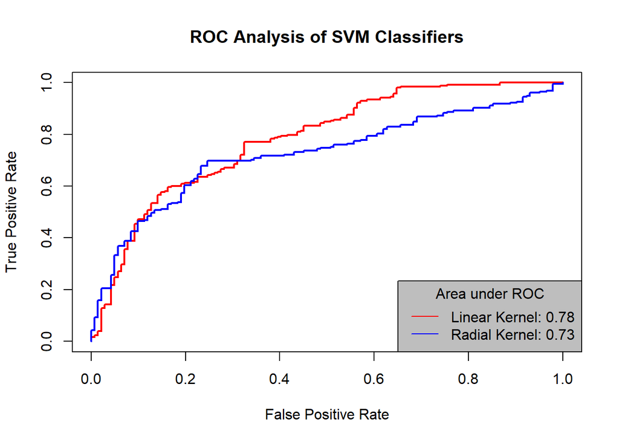

```r
# Compute performance using Linear kernel
fitted.linear <- attributes(predict(svmfit.train.C1G001, newdata=wine.testing, decision.values = TRUE))$decision.values
pred.linear.svm <- prediction(fitted.linear, wine.testing$quality)
auroc.linear.svm <- performance(pred.linear.svm, measure="auc")
auroc.linear <- auroc.linear.svm@y.values[[1]]
pr.linear.svm <- performance(pred.linear.svm, measure='tpr', x.measure='fpr')

# Computer performance using Radial kernel
fitted.radial <- attributes(predict(svmfit.radial.c5g1, newdata=wine.testing, decision.values = TRUE))$decision.values
pred.radial.svm <- prediction(fitted.radial, wine.testing$quality)
auroc.radial.svm <- performance(pred.radial.svm, measure="auc")
auroc.radial <- auroc.radial.svm@y.values[[1]]
pr.radial.svm <- performance(pred.radial.svm, measure='tpr', x.measure='fpr')

# Draw Plots and Legend
plot(pr.linear.svm, col='red', lwd=2, xlab='False Positive Rate', ylab='True Positive Rate', main='ROC Analysis of SVM Classifiers')
plot(pr.radial.svm, add=T, col='blue', lwd=2)

legend(title='Area under ROC', 'bottomright',
       c(text=sprintf('Linear Kernel: %s', round(auroc.linear, digits=2)),
         text=sprintf('Radial Kernel: %s', round(auroc.radial, digits=2))),
       lty=1, col=c('red','blue'), bg='grey')
```

Using the Area under ROC as a measure, the SVM trained with a linear kernel performs better than with a radial kerner.

# 4. Hierarchical Clustering

Consider the USArrests data. We will now perform hierarchical clustering on the states.

**(a) Using hierarchical clustering with complete linkage and Euclidean distance, cluster the states.**

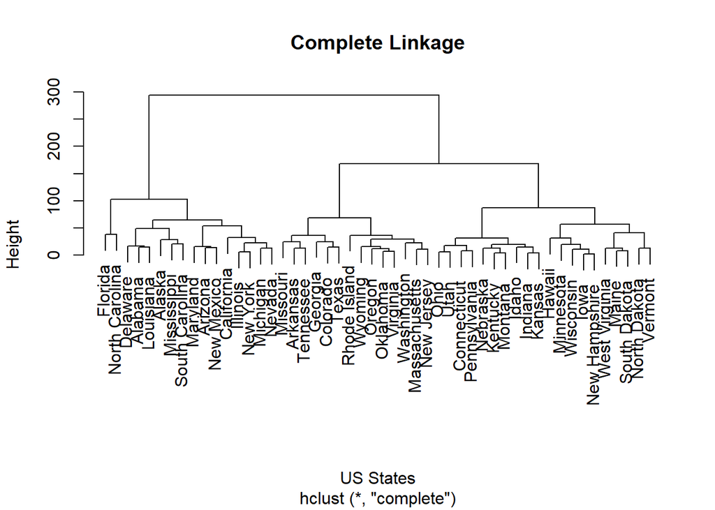

```r
data <- USArrests
data <- na.omit(data)

dis.mtrx <- dist(data, method='euclidean')
hc.comp <- hclust(dis.mtrx, method='complete')
plot(hc.comp, xlab='US States', ylab='Height', main='Complete Linkage')
```

**(b) Cut the dendrogram at a height that results in three distinct clusters. Which states belong to which clusters?**

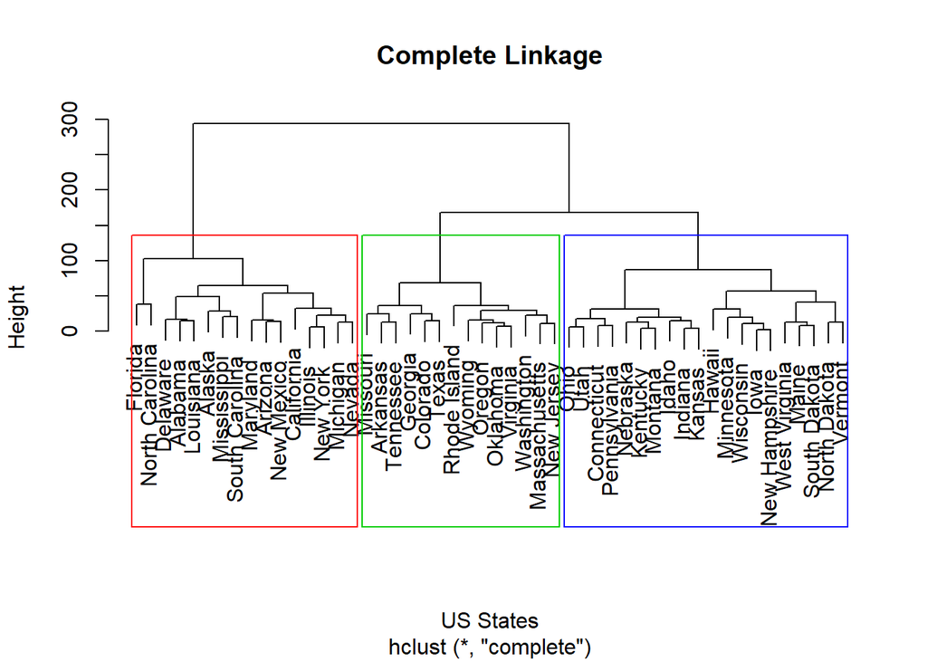

```r
hc.comp.cut3 <- cutree(hc.comp, k=3)
plot(hc.comp, xlab='US States', ylab='Height', main='Complete Linkage')
rect.hclust(hc.comp, k=3, border=c(2,3,4))
```

```r
table(hc.comp.cut3)
```

```
## hc.comp.cut3
##  1  2  3
## 16 14 20
```

```r
for(k in c(1:3)){
  print(k)
  print(rownames(data)[hc.comp.cut3==k])
}
```

```
## [1] 1
##  [1] "Alabama"        "Alaska"         "Arizona"        "California"
##  [5] "Delaware"       "Florida"        "Illinois"       "Louisiana"
##  [9] "Maryland"       "Michigan"       "Mississippi"    "Nevada"
## [13] "New Mexico"     "New York"       "North Carolina" "South Carolina"
## [1] 2
##  [1] "Arkansas"      "Colorado"      "Georgia"       "Massachusetts"
##  [5] "Missouri"      "New Jersey"    "Oklahoma"      "Oregon"
##  [9] "Rhode Island"  "Tennessee"     "Texas"         "Virginia"
## [13] "Washington"    "Wyoming"
## [1] 3
##  [1] "Connecticut"   "Hawaii"        "Idaho"         "Indiana"
##  [5] "Iowa"          "Kansas"        "Kentucky"      "Maine"
##  [9] "Minnesota"     "Montana"       "Nebraska"      "New Hampshire"
## [13] "North Dakota"  "Ohio"          "Pennsylvania"  "South Dakota"
## [17] "Utah"          "Vermont"       "West Virginia" "Wisconsin"
```

**(c) Hierarchically cluster the states using complete linkage and Euclidean distance, after scaling the variables to have standard deviation one.**

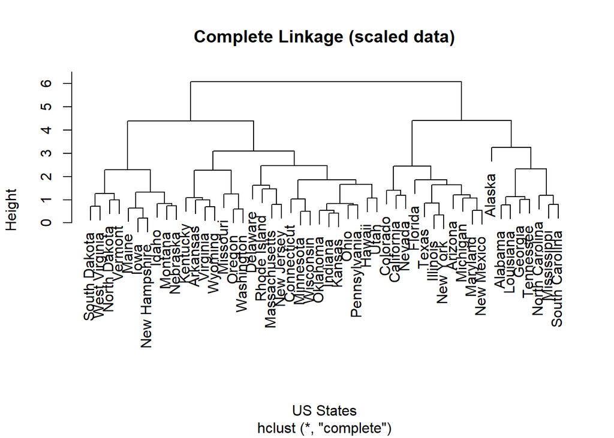

```r
data.scaled <- scale(data, scale=T)

dis.mtrx.scaled <- dist(data.scaled, method='euclidean')
hc.comp.scaled <- hclust(dis.mtrx.scaled, method='complete')
plot(hc.comp.scaled, xlab='US States', ylab='Height', main='Complete Linkage (scaled data)')
```

**(d) What effect does scaling the variables have on the hierarchical clustering obtained? In your opinion, should the variables be scaled before the inter-observation dissimilarities are computed? Provide a justification for your answer.**

```r
hc.comp.cut3.scaled <- cutree(hc.comp.scaled, k=3)
table(hc.comp.cut3.scaled)
```

```
## hc.comp.cut3.scaled
##  1  2  3
##  8 11 31
```

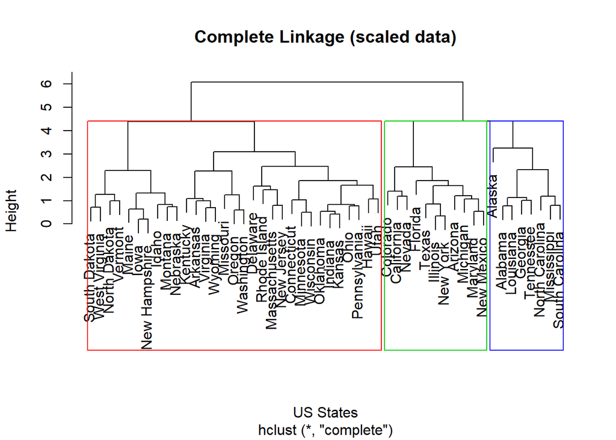

```r
plot(hc.comp.scaled, xlab='US States', ylab='Height', main='Complete Linkage (scaled data)')
rect.hclust(hc.comp.scaled, k=3, border=c(2,3,4))
```

```r
summary(data)
```

```
##      Murder          Assault         UrbanPop          Rape
##  Min.   : 0.800   Min.   : 45.0   Min.   :32.00   Min.   : 7.30
##  1st Qu.: 4.075   1st Qu.:109.0   1st Qu.:54.50   1st Qu.:15.07
##  Median : 7.250   Median :159.0   Median :66.00   Median :20.10
##  Mean   : 7.788   Mean   :170.8   Mean   :65.54   Mean   :21.23
##  3rd Qu.:11.250   3rd Qu.:249.0   3rd Qu.:77.75   3rd Qu.:26.18
##  Max.   :17.400   Max.   :337.0   Max.   :91.00   Max.   :46.00
```

```r
sapply(data, range)
```

```
##      Murder Assault UrbanPop Rape
## [1,]    0.8      45       32  7.3
## [2,]   17.4     337       91 46.0
```

We observe a change in clustering using scaled and non-scaled data, as can be observed by both tables and respective plots. Referencing the help documentation of the USArrests dataset, we see that UrbanPop is a percentage, while the other variables are numbers per 100,000. Scaling is a sensible option in this instance.

# 5. PCA and K-Means Clustering

**(a) Generate a simulated data set with 20 observations in each of three classes (i.e. 60 observations total),and 50 variables.**

```r
set.seed(10)
x1 <- matrix(runif(1000,-1,1), nrow=20, ncol=50)
for(row in 1:20){
  x1[row,] <- x1[row,] + c(runif(50,0,1))
}

x2 <- matrix(runif(1000,-1,1), nrow=20, ncol=50)
for(row in 1:20){
  x2[row,] <- x2[row,] + c(runif(50,-1,0))
}

x3 <- matrix(runif(1000,-1,1), nrow=20, ncol=50)
for(row in 1:20){
  x3[row,] <- x3[row,] + c(runif(25,-1,-0.5), runif(25,0.5,1))
}

x <- rbind(x1, x2, x3)
x.class <- c(rep(1,20), rep(2,20), rep(3,20))
```

**(b) Perform PCA on the 60 observations and plot the first two principal components’ eigenvector. Use a different color to indicate the observations in each of the three classes.**

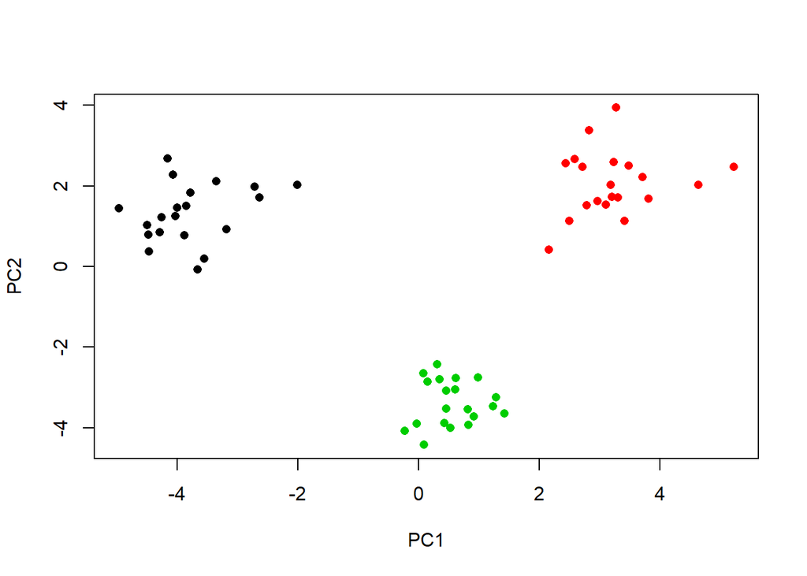

```r
pca.out <- prcomp(x, scale=F)
plot(pca.out$x[,1], pca.out$x[,2], xlab='PC1', ylab='PC2', col=x.class, pch=16)
```

**(c) Perform K-means clustering of the observations with K = 3. How well do the clusters that you obtained in K-means clustering compare to the true class labels?**

```r
km.out.3 <- kmeans(x, 3, nstart=100)
km.out.3$tot.withinss
```

```
## [1] 1167.199
```

```r
table(clustmodel=km.out.3$cluster, original=x.class)
```

```
##           original
## clustmodel  1  2  3
##          1  0  0 20
##          2  0 20  0
##          3 20  0  0
```

The model perfectly clusters 20 observations in each of the 3 clusters. NB: the model assigns a different clustering label to the original data, but this is not significant on this dataset. The choice of labeling has no material impact to the result. What matters here is that each cluster has 20 observations.

**(d) Perform K-means clustering with K = 2. Describe your results.**

```r
km.out.2 <- kmeans(x, 2, nstart=100)
km.out.2$tot.withinss
```

```
## [1] 1537.062
```

```r
table(clustmodel=km.out.2$cluster, original=x.class)
```

```
##           original
## clustmodel  1  2  3
##          1  0 20 20
##          2 20  0  0
```

The model has now combined 2 of the original clusters, leaving a third of the observations in the remaining cluster. Total WithinSS has increased somewhat, given the requirement to reduce the number of clusters, likely because cluster 1 now includes 40 observations that were originally far apart.

**(e) Now perform K-means clustering with K = 4, and describe your results.**

```r
km.out.4 <- kmeans(x, 4, nstart=100)
km.out.4$tot.withinss
```

```
## [1] 1123.657
```

```r
table(clustmodel=km.out.4$cluster, original=x.class)
```

```
##           original
## clustmodel  1  2  3
##          1  0  0 20
##          2  0 20  0
##          3 12  0  0
##          4  8  0  0
```

Now with 4 clusters, the model is able to better categorise one of the clusters, while leaving the two as they were originally. Total WithinSS has fallen back to roughly where it was with the 3 cluster model, and indeed slightly lower still because of the ability to further segregate one of the clusters.

**(f) Now perform K-means clustering with K = 3 on the first two principal components, rather than on the raw data. That is, perform K-means clustering on the 60 × 2 matrix of which the first column is the first principal component’s corresponding eigenvector, and the second column is the second principal component’s corresponding eigenvector. Comment on the results.**

```r
new_data <- pca.out$x[,1:2]

km.out.pca.3 <- kmeans(new_data, 3, nstart=100)
km.out.pca.3$tot.withinss
```

```
## [1] 52.20187
```

```r
table(clustmodel=km.out.pca.3$cluster, original=x.class)
```

```
##           original
## clustmodel  1  2  3
##          1 20  0  0
##          2  0  0 20
##          3  0 20  0
```

This model also perfectly clusters the observations into 3 classes. Again, the cluster labels are not important. Having stripped the data down into its first two principal components, total withinSS has dramatically reduced.

**(g) Using the scale() function, perform K-means clustering with K = 3 on the data after scaling each variable to have standard deviation one. How do these results compare to the true class labels? Will the scaling affect the clustering?**

```r
scaled.x <- scale(x)

km.out.scaled.3 <- kmeans(scaled.x, 3, nstart=100)
km.out.scaled.3$tot.withinss
```

```
## [1] 1717.191
```

```r
table(clustmodel=km.out.scaled.3$cluster, original=x.class)
```

```
##           original
## clustmodel  1  2  3
##          1  0 20  0
##          2 20  0  0
##          3  0  0 20
```

Having scaled the data, the model has correctly clustered the observations. However, this is no different to the unscaled data, so the scaling did not affect the clustering. Perhaps worth noting though that the total within-cluster sum of squares was materially higher on the scaled data. We aim to minimise this value when performing such clustering methods.